# assignment3_jml

Jahred Liddie

9/18/2021

```r
# load packages per tutorial
library(sf)
library(tidyverse)
library(ggthemes)
library(ggspatial)
library(units)
library(nngeo)
library(kableExtra) # for making nice tables

# load data
  # MBTA bus stops (points)
  bus <- st_read("MBTA_Bus_Stops.geojson", quiet = TRUE)

  # Boston census tracts (polygons)
  tracts <- st_read("https://bostonopendata-boston.opendata.arcgis.com/datasets/4a8eb4fb3be44ed5a1eec28551b9f3b2_0.geojson?outSR=%7B%22latestWkid%22%3A3857%2C%22wkid%22%3A102100%7D", quiet = TRUE) # polgyon: census tracts

    # full census tract demographic data
    demo <- read.csv("ACS2014_2018_tract.csv")
    demo <- demo %>% select(GEOID, homeowner, renter, poverty) # select some data
    demo$GEOID <- as.character(demo$GEOID) # make into character for merging

      # check GEOIDs, then merge some data with Boston tracts
      setdiff(tracts$GEOID10, demo$GEOID)
```

```
## character(0)
```

```r
      tracts <- left_join(tracts, demo, by = c("GEOID10" = "GEOID")) # merge columns into tracts
      rm(demo) # drop dataset

      # create quartiles of each of these columns as well
      tracts <- tracts %>%
        mutate(q.homeowner = ifelse(!is.na(ntile(homeowner,4)),
                                    paste("Q", ntile(homeowner, 4), sep = ""), NA), # this lets no data be NA
               q.renter = ifelse(!is.na(ntile(renter,4)),
                                    paste("Q", ntile(renter, 4), sep = ""), NA),
               q.poverty = ifelse(!is.na(ntile(poverty,4)),
                                    paste("Q", ntile(poverty, 4), sep = ""), NA),
        )

  # Boston nhoods (polygons)
  nhoods <- st_read("http://bostonopendata-boston.opendata.arcgis.com/datasets/3525b0ee6e6b427f9aab5d0a1d0a1a28_0.kml", quiet = TRUE)

  # Boston public schools (points)
  schools <- st_read("https://bostonopendata-boston.opendata.arcgis.com/datasets/1d9509a8b2fd485d9ad471ba2fdb1f90_0.geojson?outSR=%7B%22latestWkid%22%3A2249%2C%22wkid%22%3A102686%7D", quiet = TRUE)

  # Water (polygon)
  water <- st_read("http://bostonopendata-boston.opendata.arcgis.com/datasets/2b3c0fa13b1c468eb702a3645fcc6bcb_5.kml", quiet = TRUE)

  knitr::opts_chunk$set(echo = TRUE)
```

# Transforming data

Transform relevant data to the Massachusetts State Plane system.

```r
MA_state_plane <- "+proj=lcc +lat_1=41.71666666666667 +lat_2=42.68333333333333 +lat_0=41 +lon_0=-71.5 +x_0=200000 +y_0=750000 +ellps=GRS80 +units=m +no_defs"

nhoods <- nhoods %>%
  st_transform(MA_state_plane)

water <- water %>%
  st_transform(MA_state_plane)

tracts <- tracts %>%
  st_transform(MA_state_plane)

bus <- bus %>%
  st_transform(MA_state_plane)

schools <- schools %>%
  st_transform(MA_state_plane)
```

Then, trim bus stops to be just within Boston.

```r
# check validity of geometry before intersecting
sum(st_is_valid(bus)==F)
```

```
## [1] 0
```

```r
sum(st_is_valid(nhoods)==F) # this has one invalid geometry
```

```
## [1] 1
```

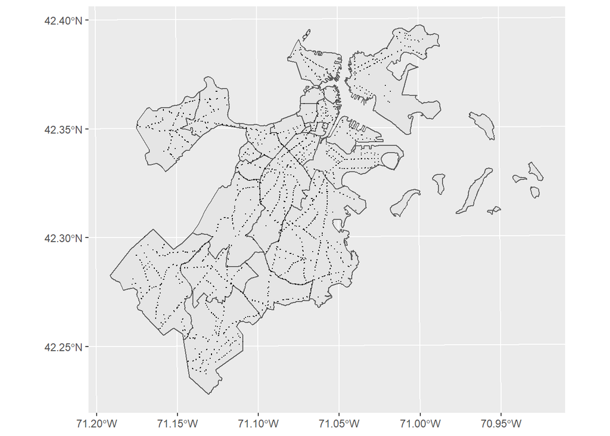

```r
# make nhoods valid
nhoods.valid <- st_make_valid(nhoods)

# # compare nhoods
# ggplot(nhoods.valid) +
#   geom_sf()
#
# ggplot(nhoods) +
#   geom_sf()

# intersection of bus dataset with Boston neighborhoods
bus_boston <- st_intersection(nhoods.valid, bus)

# map of new bus dataset
ggplot(nhoods) +
  geom_sf() +
  geom_sf(data = bus_boston, size = 0.1, color = "black")
```

Basic map of bus stops (black) and public schools (red).

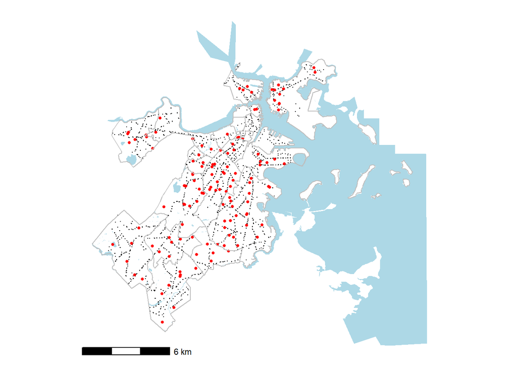

```r
ggplot(water) +
  geom_sf(fill = "lightblue", color = NA) +
  geom_sf(data = bus_boston, color = "black", size = 0.1) +
  geom_sf(data = schools, size = 1, color = "red") +
  geom_sf(data= nhoods, fill = NA, color = "gray") +
  theme_map() +
  annotation_scale()
```

# Creating buffers

Create buffers around schools and subset bus stops to the buffers

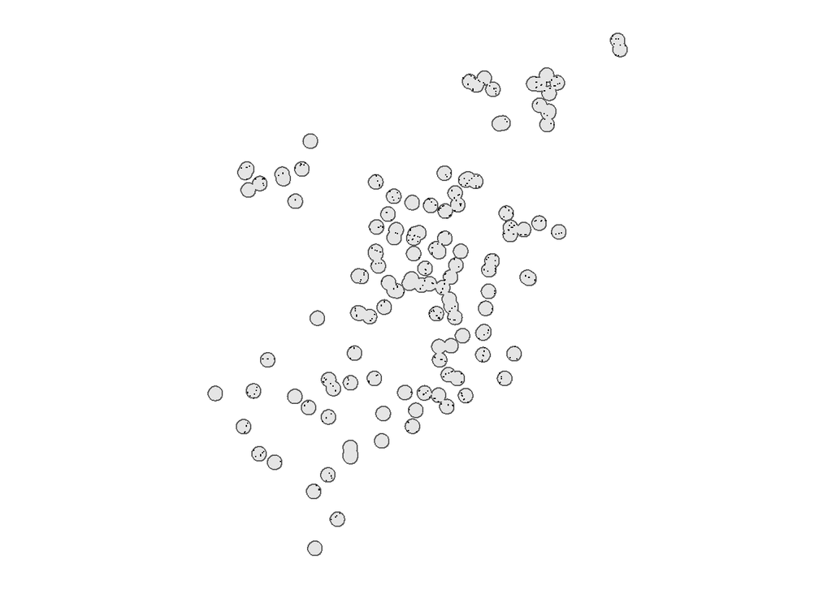

```r
schools_buffer <- st_buffer(schools, dist = 250) %>%
  st_union() # 250 m buffers around public schools

# # map of buffers
# ggplot(schools_buffer) +
#   geom_sf() +
#   theme_map()

bus_schools <- bus_boston[schools_buffer,]

ggplot(schools_buffer) +
  geom_sf() +
  geom_sf(data = bus_schools,
          color = "black",
          size = 0.1) +
  theme_map()
```

# Map 1

Number and proportion of bus stops within 250 meters of Boston public schools [question 1].

```r
# join buffers with bus data
bus_boston <- bus_boston %>%
  st_join(bus_schools) %>%
  mutate(by_schools = !is.na(Name.y)) # indicator of being in buffers


# number and proportion in buffers
n_bus_schools <- sum(bus_boston$by_schools)
pct_bus_schools <- sum(bus_boston$by_schools) / length(bus_boston$by_schools)

bus_boston %>% st_drop_geometry %>% summarise( # drop sf for output
  "Number of bus stops within 250 m buffers" = sum(by_schools),
  "Proportion of bus stops in 250 m buffers" = round(sum(by_schools)/n(), 3)*100
)
```

```
##   Number of bus stops within 250 m buffers
## 1                                      571
##   Proportion of bus stops in 250 m buffers
## 1                                     25.9
```

So, 571 Boston bus stops are within 250 meters of a public school, representing 25.9% of all bus stops in Boston.

**Map 1:**

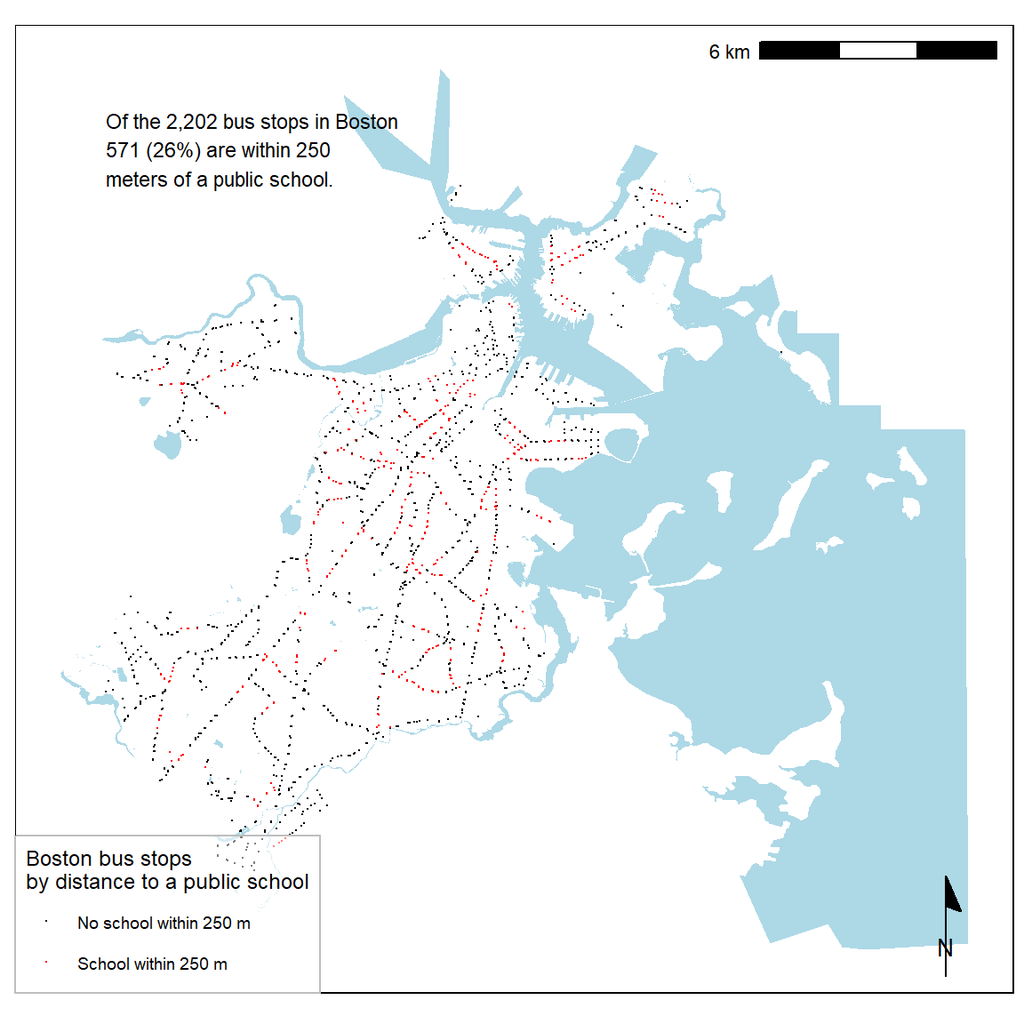

```r
left_side  <- st_bbox(bus_boston)$xmin
top_side <- st_bbox(bus_boston)$ymax # this is for adding note to the top left of map

ggplot(water) +
  geom_sf(fill = "lightblue", color = NA) +
  geom_sf(data = bus_boston, size = 0.1,
          aes(color = by_schools)) +
  scale_color_manual(values = c("black", "red"),
          name = "Boston bus stops\nby distance to a public school",
          labels = c("No school within 250 m",
                     "School within 250 m")) +
  annotation_scale(location = "tr") +
  annotation_north_arrow(location = "br",
                         style = north_arrow_minimal()) +
  annotate(geom = "text", x = left_side,
           y = top_side,
           label = paste("Of the ",
                         prettyNum(length(bus_boston$by_schools), big.mark = ","),
                         " bus stops in Boston\n",
                         prettyNum(n_bus_schools, big.mark = ","),
                         " (",
                         prettyNum(100*pct_bus_schools, digits = 0),
                         "%) are within 250\nmeters of a public school.",
                         sep = ""),
           hjust = 0, vjust = 0, size = 3) +
  theme_map() +
  theme(panel.background = element_rect(fill = "white"),
        legend.background = element_rect(fill = alpha("white", 0.5),
                                         color = "gray"))
```

# Map 2

Number of bus stops within each Boston neighborhood [question 5].

```r
nhoods <- nhoods %>%
  mutate(num_bus = lengths(st_covers(nhoods, bus_boston)))


# which nhood has the most number of bus stops and what proportion?
max.bus.nhood <- nhoods$Name[nhoods$num_bus == max(nhoods$num_bus)]
max.bus <- max(nhoods$num_bus)
prop.max.bus <- max(nhoods$num_bus)/nrow(bus_boston)

# number and proportion in each nhood
kableExtra::kable(
  nhoods %>% group_by(Name) %>%
  st_drop_geometry() %>%
  summarise(
  "Total bus stops" = num_bus,
  "Proportion of total stops" = round(num_bus/nrow(bus_boston)*100, 1)) %>%
  ungroup()
)
```

| Name | Total bus stops | Proportion of total stops |
| --- | --- | --- |
| Allston | 70 | 3.2 |
| Back Bay | 38 | 1.7 |
| Bay Village | 2 | 0.1 |
| Beacon Hill | 14 | 0.6 |
| Brighton | 121 | 5.5 |
| Charlestown | 68 | 3.1 |
| Chinatown | 4 | 0.2 |
| Dorchester | 382 | 17.3 |
| Downtown | 82 | 3.7 |
| East Boston | 137 | 6.2 |
| Fenway | 68 | 3.1 |
| Harbor Islands | 1 | 0.0 |
| Hyde Park | 168 | 7.6 |
| Jamaica Plain | 109 | 5.0 |
| Leather District | 2 | 0.1 |
| Longwood | 20 | 0.9 |
| Mattapan | 78 | 3.5 |
| Mission Hill | 44 | 2.0 |
| North End | 8 | 0.4 |
| Roslindale | 131 | 5.9 |
| Roxbury | 219 | 9.9 |
| South Boston | 130 | 5.9 |
| South Boston Waterfront | 36 | 1.6 |
| South End | 68 | 3.1 |
| West End | 12 | 0.5 |
| West Roxbury | 190 | 8.6 |

**Map 2:**

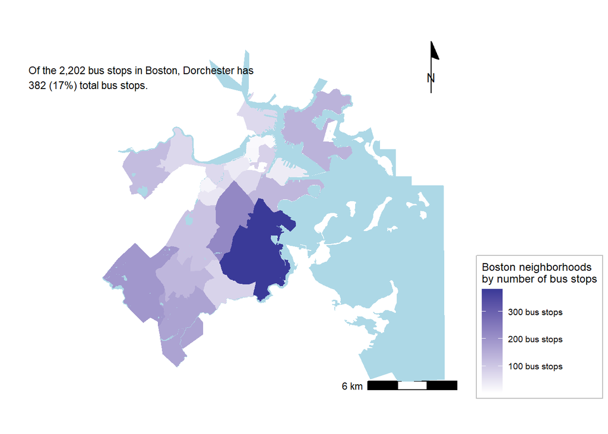

```r
left_side  <- st_bbox(nhoods)$xmin - 5000 # better location for text
top_side <- st_bbox(nhoods)$ymax

ggplot(nhoods) +
  geom_sf(color = NA,
          aes(fill = num_bus)) +
  scale_fill_gradient2(name = "Boston neighborhoods\nby number of bus stops",
                       breaks = breaks <- seq(0, 400, by = 100),
                       labels = paste(prettyNum(breaks, big.mark = ","),
                                      "bus stops")) +
  annotation_scale(location = "br") +
  annotation_north_arrow(location = "tr",
                         style = north_arrow_minimal()) +
  geom_sf(data = water, fill = "lightblue", color = NA) +
  annotate(geom = "text", x = left_side,
           y = top_side,
           label = paste("Of the ",
                         prettyNum(nrow(bus_boston), big.mark = ","),
                         " bus stops in Boston, Dorchester has \n",
                         prettyNum(max.bus, big.mark = ","),
                         " (",
                         prettyNum(100*prop.max.bus, digits = 0),
                         "%) total bus stops.",
                         sep = ""),
           hjust = 0, vjust = 0, size = 3) +
  theme_map() +
  theme(legend.position = "right",
        legend.background = element_rect(fill = alpha("white", 0.5),
                                         color = "gray"))
```

# Map 3

Areal density of bus stops within each Boston neighborhood [question 19].

```r
nhoods <- nhoods %>%
  mutate(area = set_units(st_area(nhoods), km^2)) %>%
  mutate(bus_dens = as.numeric(num_bus / area))

# which nhood has the greatest density of stops?
max.bus.density.nhood <- nhoods$Name[nhoods$bus_dens == max(nhoods$bus_dens)]
max.bus.density <- max(nhoods$bus_dens)

# number and density in each nhood
kableExtra::kable(
  nhoods %>% group_by(Name) %>%
  st_drop_geometry() %>%
  summarise(
  "Total bus stops" = num_bus,
  "Proportion of total stops" = round(num_bus/nrow(bus_boston)*100, 1),
  "Density of stops [stops per km^2]" = round(bus_dens, 1)) %>%
  ungroup()
)
```

| Name | Total bus stops | Proportion of total stops | Density of stops [stops per km^2] |
| --- | --- | --- | --- |
| Allston | 70 | 3.2 | 17.3 |
| Back Bay | 38 | 1.7 | 23.5 |
| Bay Village | 2 | 0.1 | 18.6 |
| Beacon Hill | 14 | 0.6 | 17.3 |
| Brighton | 121 | 5.5 | 16.2 |
| Charlestown | 68 | 3.1 | 19.3 |
| Chinatown | 4 | 0.2 | 13.0 |
| Dorchester | 382 | 17.3 | 20.2 |
| Downtown | 82 | 3.7 | 51.0 |
| East Boston | 137 | 6.2 | 11.2 |
| Fenway | 68 | 3.1 | 30.0 |
| Harbor Islands | 1 | 0.0 | 0.3 |
| Hyde Park | 168 | 7.6 | 14.2 |
| Jamaica Plain | 109 | 5.0 | 10.7 |
| Leather District | 2 | 0.1 | 31.6 |
| Longwood | 20 | 0.9 | 26.2 |
| Mattapan | 78 | 3.5 | 14.3 |
| Mission Hill | 44 | 2.0 | 31.0 |
| North End | 8 | 0.4 | 15.6 |
| Roslindale | 131 | 5.9 | 20.2 |
| Roxbury | 219 | 9.9 | 25.7 |
| South Boston | 130 | 5.9 | 22.3 |
| South Boston Waterfront | 36 | 1.6 | 14.3 |
| South End | 68 | 3.1 | 35.6 |
| West End | 12 | 0.5 | 15.6 |
| West Roxbury | 190 | 8.6 | 13.4 |

**Map 3:**

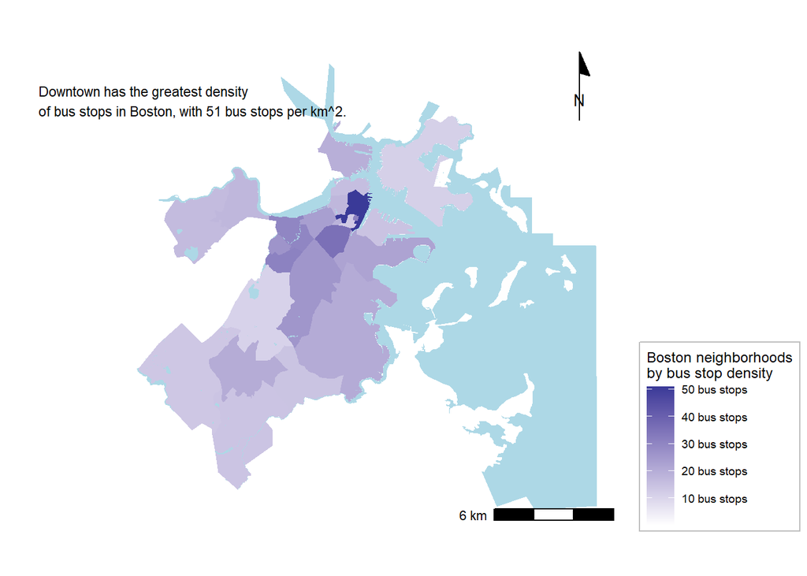

```r
ggplot(nhoods) +
  geom_sf(color = NA,
          aes(fill = bus_dens)) +
  scale_fill_gradient2(name = "Boston neighborhoods\nby bus stop density",
                       breaks = breaks <- seq(0, 70, by = 10),
                       labels = paste(prettyNum(breaks, big.mark = ","),
                                      "bus stops")) +
  geom_sf(data = water, fill = "lightblue", color = NA) +
  annotation_scale(location = "br") +
  annotation_north_arrow(location = "tr",
                         style = north_arrow_minimal()) +
  annotate(geom = "text", x = left_side,
           y = top_side,
           label = paste("Downtown has the greatest density \n",
                         "of bus stops in Boston, with ",
                         prettyNum(round(max.bus.density, 1), big.mark = ","),
                         " bus stops per km^2.",
                         sep = ""),
           hjust = 0, vjust = 0, size = 3) +
  theme_map() +
  theme(legend.position = "right",
    legend.background = element_rect(fill = alpha("white", 0.5),
                                         color = "gray"))
```

# Map 4

Number of bus stops within each Boston census tract [question 6].

**Map 4**

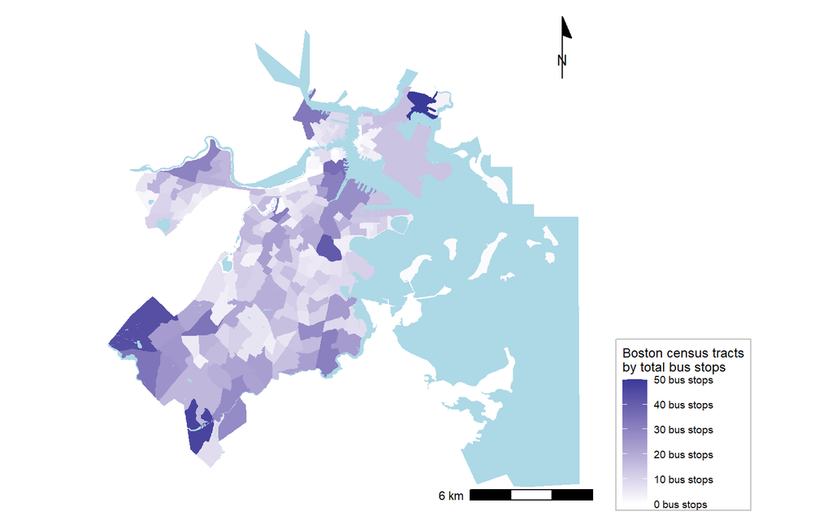

```r
# drop census tract with all water for plotting purposes
tracts <- subset(tracts, FID != 48)

# calculate total and areal density
tracts <- tracts %>%
  mutate(num_bus = lengths(st_covers(tracts, bus_boston))) %>%
  mutate(area = set_units(st_area(tracts), km^2)) %>%
  mutate(bus_dens = as.numeric(num_bus / area))


ggplot(tracts) +
  geom_sf(color = NA,
          aes(fill = num_bus)) +
  scale_fill_gradient2(name = "Boston census tracts\nby total bus stops",
                       breaks = breaks <- seq(0, 50, by = 10),
                       labels = paste(prettyNum(breaks, big.mark = ","),
                                      "bus stops")) +
  geom_sf(data = water, fill = "lightblue", color = NA) +
  annotation_scale(location = "br") +
  annotation_north_arrow(location = "tr",
                         style = north_arrow_minimal()) +
  theme_map() +
  theme(legend.position = "right",
    legend.background = element_rect(fill = alpha("white", 0.5),
                                         color = "gray"))
```

**Map 4 (cont): faceting by quartile of residents under the poverty line**

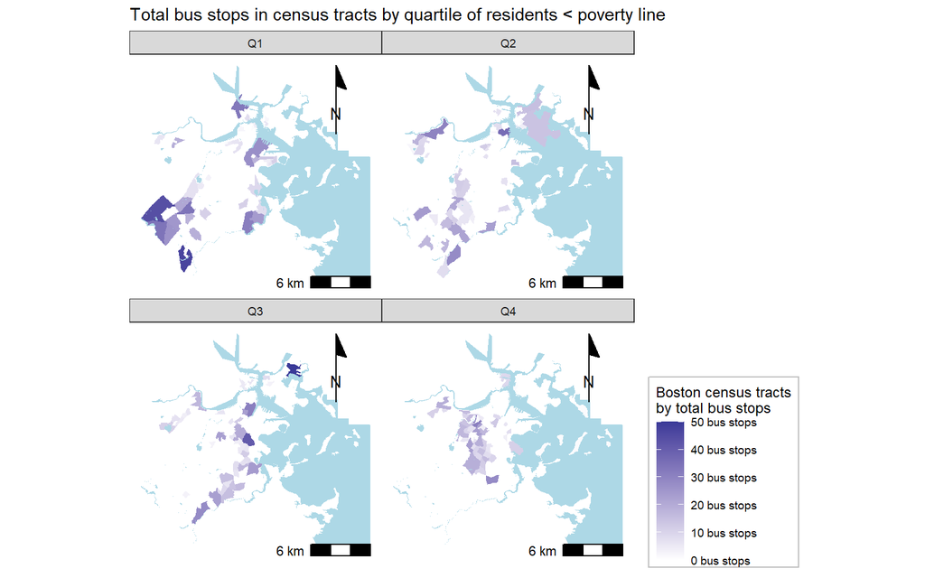

```r
# note: this drops any tracts with no poverty data
ggplot(subset(tracts, !is.na(q.poverty))) +
  geom_sf(color = NA,
          aes(fill = num_bus)) +
  scale_fill_gradient2(name = "Boston census tracts\nby total bus stops",
                       breaks = breaks <- seq(0, 50, by = 10),
                       labels = paste(prettyNum(breaks, big.mark = ","),
                                      "bus stops")) +
  geom_sf(data = water, fill = "lightblue", color = NA) +
  annotation_scale(location = "br") +
  annotation_north_arrow(location = "tr",
                         style = north_arrow_minimal()) +
  theme_map() +
  labs(title = "Total bus stops in census tracts by quartile of residents < poverty line") +
  theme(legend.position = "right",
    legend.background = element_rect(fill = alpha("white", 0.5),
                                         color = "gray")) +
  facet_wrap(~q.poverty)
```

# Map 5

Areal density of bus stops in each census tract [question 20].

**Map 5:**

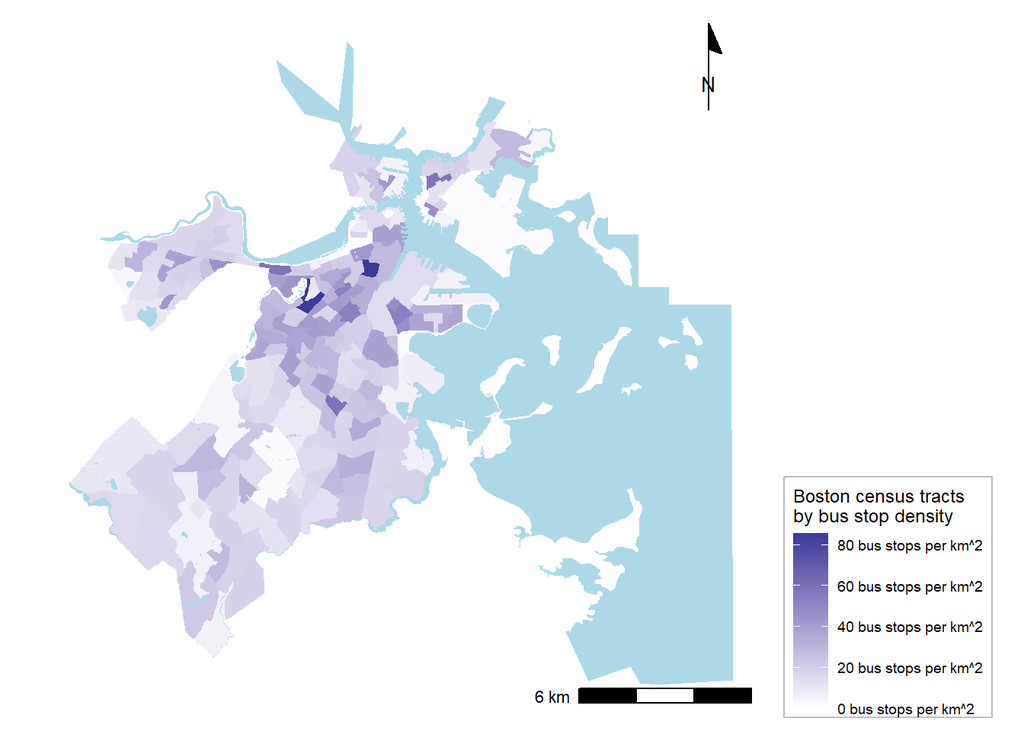

```r
ggplot(tracts) +
  geom_sf(color = NA,
          aes(fill = bus_dens)) +
  scale_fill_gradient2(name = "Boston census tracts\nby bus stop density",
                       breaks = breaks <- seq(0, 100, by = 20),
                       labels = paste(prettyNum(breaks, big.mark = ","),
                                      "bus stops per km^2")) +
  geom_sf(data = water, fill = "lightblue", color = NA) +
  annotation_scale(location = "br") +
  annotation_north_arrow(location = "tr",
                         style = north_arrow_minimal()) +
  theme_map() +
  theme(legend.position = "right",
    legend.background = element_rect(fill = alpha("white", 0.5),
                                         color = "gray"))
```

**Map 5 (cont): areal density faceted by quartile of residents under the poverty line**

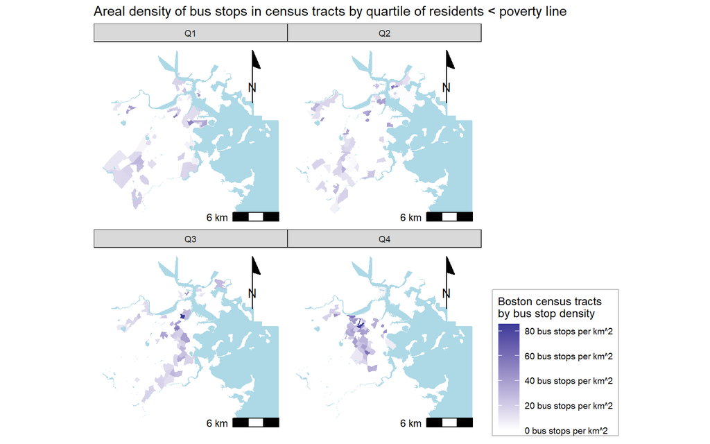

```r
ggplot(subset(tracts, !is.na(q.poverty))) +
  geom_sf(color = NA,
          aes(fill = bus_dens)) +
  scale_fill_gradient2(name = "Boston census tracts\nby bus stop density",
                       breaks = breaks <- seq(0, 100, by = 20),
                       labels = paste(prettyNum(breaks, big.mark = ","),
                                      "bus stops per km^2")) +
  geom_sf(data = water, fill = "lightblue", color = NA) +
  annotation_scale(location = "br") +
  annotation_north_arrow(location = "tr",
                         style = north_arrow_minimal()) +
  theme_map() +
  theme(legend.position = "right",
    legend.background = element_rect(fill = alpha("white", 0.5),
                                         color = "gray")) +
  labs(title = "Areal density of bus stops in census tracts by quartile of residents < poverty line") +
  facet_wrap(~q.poverty)
```

# Map 6

First, calculate these distances.

```r
# nearest bus and distance to each school
schools = schools %>%
  mutate(bus_distance = st_nn(schools, bus_boston,
                              returnDist = TRUE)$dist) %>%
  mutate(bus_distance = as.numeric(bus_distance))
```

```
## projected points
```

```r
avg.dist <- mean(schools$bus_distance) # calculate average distance across all schools
```

**Map 6:**

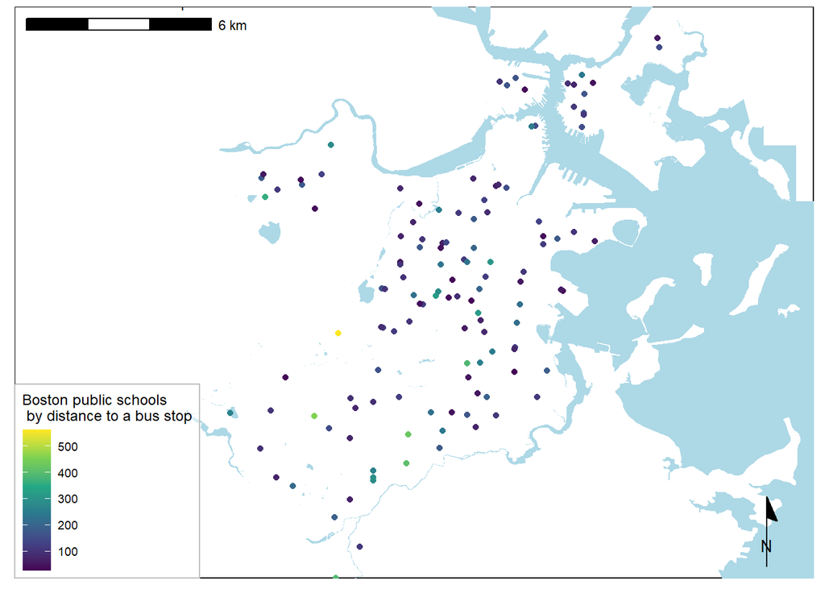

```r
right_side <- st_bbox(schools)$xmax + 5000 # small edits for plotting extent
left_side <- st_bbox(schools)$xmin - 7000
top_side <- st_bbox(schools)$ymax + 1000
bottom_side <- st_bbox(schools)$ymin

ggplot(water) +
  geom_sf(fill = "lightblue", color = NA) +
  geom_sf(data = schools, size = 1.5,
          aes(color = bus_distance)) +
  coord_sf(xlim = c(left_side, right_side),
           ylim = c(bottom_side, top_side), expand = FALSE) +
  scale_color_viridis_c(name = "Boston public schools \n by distance to a bus stop") +
  annotation_scale(location = "tl") +
  annotation_north_arrow(location = "br",
                         style = north_arrow_minimal()) +
  annotate(geom = "text", x = left_side,
           y = top_side,
           label = paste("Overall, a Boston public school is \n ",
                         prettyNum(avg.dist, digits = 2),
                         " meters from a bus stop.",
                         sep = ""),
           hjust = 0, vjust = 0, size = 3) +
  theme_map() +
  theme(panel.background = element_rect(fill = "white"),
        legend.background = element_rect(fill = alpha("white", 0.5),
                                         color = "gray"))
```

# Contribution statement